# Part I - (Prosper Loan Data Exploration)

## Introduction

In this "Communicate Data Findings" project, I will be analyzing the Prosper loan dataset to determine the relationship between its features. Univariate plots will be plotted to discover the distribution of selected features after which bivariate plots will be made to uncover the effect of one feature on the other and lastly multivariate plots will be plotted based on the trends discovered in the previous plots to find out if addition of more features strengthens the relationsips found.

Dataset description: The Prosper loan dataset contains information from over 113,000 loans from Prosper marketplace which is a peer-to-peer lending marketplace in the United States founded in 2005. The dataset consists of 113937 rows with 81 variables (columns) on each loan, including loan original amount, borrower rate, current loan status, borrower income, and many others.

#### Questions for analysis

1. What are the distributions of some of the variables of interest?
2. How did borrowers without prosper rating fare in the status of the their loan?
3. Does prosper rating after Borrower's Annual percentage rate?
4. Is BorrowerAPR the reason for the distribution observed in years 2013 and 2014?
5. Does income range influence borrowerAPR?
6. What is the relationship between BorrowerAPR and DebtToIncomeRatio?
7. What was the borrowerAPR of borrowers without prosper rating?
8. What was the borrowerAPR of borrowers without prosper rating?
9. What kind of Terms were given to borrowers based on their Prosper rating?
10. Does Debt-to-income ratio have an effect on borrowers' loan status?
11. What is the relationship between ProsperRating_Combined and DebtToIncomeRatio?
12. Do more investors go to high income earners?
13. What was the reason for the distribution observed in years 2013 and 2014?
14. Does being a group member influence BorrowerAPR for borrowers without ProsperRating_Combined value?
15. What is the effect of Term on BorrowerAPR and ProsperRating_Combined?
16. What is the relationship of Borrower Annual Percentage Rate across ProsperRating_Combined and IncomeRange?
17. What is the effect of Income range across DebtToIncomeRatio and ProsperRating_Combined?

## Preliminary Wrangling

```python
# import all packages and set plots to be embedded inline
import numpy as np
import pandas as pd
import matplotlib.pyplot as plt
import seaborn as sb

%matplotlib inline
```

```python
# load in the dataset into a pandas dataframe
prosper = pd.read_csv('prosperLoanData.csv')
```

```python
#view of prosper data shape
prosper.shape
```

```
(113937, 81)
```

```python
#view prosper data information
prosper.info()
```

```
<class 'pandas.core.frame.DataFrame'>
RangeIndex: 113937 entries, 0 to 113936
Data columns (total 81 columns):
ListingKey                             113937 non-null object
ListingNumber                          113937 non-null int64
ListingCreationDate                    113937 non-null object
CreditGrade                            28953 non-null object
Term                                   113937 non-null int64
LoanStatus                             113937 non-null object
ClosedDate                             55089 non-null object
BorrowerAPR                            113912 non-null float64
BorrowerRate                           113937 non-null float64
LenderYield                            113937 non-null float64
EstimatedEffectiveYield                84853 non-null float64
EstimatedLoss                          84853 non-null float64
EstimatedReturn                        84853 non-null float64
ProsperRating (numeric)                84853 non-null float64
ProsperRating (Alpha)                  84853 non-null object
ProsperScore                           84853 non-null float64
ListingCategory (numeric)              113937 non-null int64
BorrowerState                          108422 non-null object
Occupation                             110349 non-null object
EmploymentStatus                       111682 non-null object
EmploymentStatusDuration               106312 non-null float64
IsBorrowerHomeowner                    113937 non-null bool
CurrentlyInGroup                       113937 non-null bool
GroupKey                               13341 non-null object
DateCreditPulled                       113937 non-null object
CreditScoreRangeLower                  113346 non-null float64
CreditScoreRangeUpper                  113346 non-null float64
FirstRecordedCreditLine                113240 non-null object
CurrentCreditLines                     106333 non-null float64
OpenCreditLines                        106333 non-null float64
TotalCreditLinespast7years             113240 non-null float64
OpenRevolvingAccounts                  113937 non-null int64
OpenRevolvingMonthlyPayment            113937 non-null float64
InquiriesLast6Months                   113240 non-null float64
TotalInquiries                         112778 non-null float64
CurrentDelinquencies                   113240 non-null float64
AmountDelinquent                       106315 non-null float64
```

[output cut: 31 more lines]

```
LP_CustomerPayments                    113937 non-null float64
LP_CustomerPrincipalPayments           113937 non-null float64
LP_InterestandFees                     113937 non-null float64
LP_ServiceFees                         113937 non-null float64
LP_CollectionFees                      113937 non-null float64
LP_GrossPrincipalLoss                  113937 non-null float64
LP_NetPrincipalLoss                    113937 non-null float64
LP_NonPrincipalRecoverypayments        113937 non-null float64
PercentFunded                          113937 non-null float64
Recommendations                        113937 non-null int64
InvestmentFromFriendsCount             113937 non-null int64
InvestmentFromFriendsAmount            113937 non-null float64
Investors                              113937 non-null int64
dtypes: bool(3), float64(50), int64(11), object(17)
memory usage: 68.1+ MB
```

```python
# descriptive statistics for numeric variables
prosper.describe()
```

|  | ListingNumber | Term | BorrowerAPR | BorrowerRate | LenderYield | EstimatedEffectiveYield | EstimatedLoss | EstimatedReturn | ProsperRating (numeric) | ProsperScore | ... | LP_ServiceFees | LP_CollectionFees | LP_GrossPrincipalLoss | LP_NetPrincipalLoss | LP_NonPrincipalRecoverypayments | PercentFunded | Recommendations | InvestmentFromFriendsCount | InvestmentFromFriendsAmount | Investors |
| --- | --- | --- | --- | --- | --- | --- | --- | --- | --- | --- | --- | --- | --- | --- | --- | --- | --- | --- | --- | --- | --- |
| count | 1.139370e+05 | 113937.000000 | 113912.000000 | 113937.000000 | 113937.000000 | 84853.000000 | 84853.000000 | 84853.000000 | 84853.000000 | 84853.000000 | ... | 113937.000000 | 113937.000000 | 113937.000000 | 113937.000000 | 113937.000000 | 113937.000000 | 113937.000000 | 113937.000000 | 113937.000000 | 113937.000000 |
| mean | 6.278857e+05 | 40.830248 | 0.218828 | 0.192764 | 0.182701 | 0.168661 | 0.080306 | 0.096068 | 4.072243 | 5.950067 | ... | -54.725641 | -14.242698 | 700.446342 | 681.420499 | 25.142686 | 0.998584 | 0.048027 | 0.023460 | 16.550751 | 80.475228 |
| std | 3.280762e+05 | 10.436212 | 0.080364 | 0.074818 | 0.074516 | 0.068467 | 0.046764 | 0.030403 | 1.673227 | 2.376501 | ... | 60.675425 | 109.232758 | 2388.513831 | 2357.167068 | 275.657937 | 0.017919 | 0.332353 | 0.232412 | 294.545422 | 103.239020 |
| min | 4.000000e+00 | 12.000000 | 0.006530 | 0.000000 | -0.010000 | -0.182700 | 0.004900 | -0.182700 | 1.000000 | 1.000000 | ... | -664.870000 | -9274.750000 | -94.200000 | -954.550000 | 0.000000 | 0.700000 | 0.000000 | 0.000000 | 0.000000 | 1.000000 |
| 25% | 4.009190e+05 | 36.000000 | 0.156290 | 0.134000 | 0.124200 | 0.115670 | 0.042400 | 0.074080 | 3.000000 | 4.000000 | ... | -73.180000 | 0.000000 | 0.000000 | 0.000000 | 0.000000 | 1.000000 | 0.000000 | 0.000000 | 0.000000 | 2.000000 |
| 50% | 6.005540e+05 | 36.000000 | 0.209760 | 0.184000 | 0.173000 | 0.161500 | 0.072400 | 0.091700 | 4.000000 | 6.000000 | ... | -34.440000 | 0.000000 | 0.000000 | 0.000000 | 0.000000 | 1.000000 | 0.000000 | 0.000000 | 0.000000 | 44.000000 |
| 75% | 8.926340e+05 | 36.000000 | 0.283810 | 0.250000 | 0.240000 | 0.224300 | 0.112000 | 0.116600 | 5.000000 | 8.000000 | ... | -13.920000 | 0.000000 | 0.000000 | 0.000000 | 0.000000 | 1.000000 | 0.000000 | 0.000000 | 0.000000 | 115.000000 |
| max | 1.255725e+06 | 60.000000 | 0.512290 | 0.497500 | 0.492500 | 0.319900 | 0.366000 | 0.283700 | 7.000000 | 11.000000 | ... | 32.060000 | 0.000000 | 25000.000000 | 25000.000000 | 21117.900000 | 1.012500 | 39.000000 | 33.000000 | 25000.000000 | 1189.000000 |

8 rows × 61 columns

```python
#view the first 10 records of prosper data
prosper.head(10)
```

|  | ListingKey | ListingNumber | ListingCreationDate | CreditGrade | Term | LoanStatus | ClosedDate | BorrowerAPR | BorrowerRate | LenderYield | ... | LP_ServiceFees | LP_CollectionFees | LP_GrossPrincipalLoss | LP_NetPrincipalLoss | LP_NonPrincipalRecoverypayments | PercentFunded | Recommendations | InvestmentFromFriendsCount | InvestmentFromFriendsAmount | Investors |
| --- | --- | --- | --- | --- | --- | --- | --- | --- | --- | --- | --- | --- | --- | --- | --- | --- | --- | --- | --- | --- | --- |
| 0 | 1021339766868145413AB3B | 193129 | 2007-08-26 19:09:29.263000000 | C | 36 | Completed | 2009-08-14 00:00:00 | 0.16516 | 0.1580 | 0.1380 | ... | -133.18 | 0.0 | 0.0 | 0.0 | 0.0 | 1.0 | 0 | 0 | 0.0 | 258 |
| 1 | 10273602499503308B223C1 | 1209647 | 2014-02-27 08:28:07.900000000 | NaN | 36 | Current | NaN | 0.12016 | 0.0920 | 0.0820 | ... | 0.00 | 0.0 | 0.0 | 0.0 | 0.0 | 1.0 | 0 | 0 | 0.0 | 1 |
| 2 | 0EE9337825851032864889A | 81716 | 2007-01-05 15:00:47.090000000 | HR | 36 | Completed | 2009-12-17 00:00:00 | 0.28269 | 0.2750 | 0.2400 | ... | -24.20 | 0.0 | 0.0 | 0.0 | 0.0 | 1.0 | 0 | 0 | 0.0 | 41 |
| 3 | 0EF5356002482715299901A | 658116 | 2012-10-22 11:02:35.010000000 | NaN | 36 | Current | NaN | 0.12528 | 0.0974 | 0.0874 | ... | -108.01 | 0.0 | 0.0 | 0.0 | 0.0 | 1.0 | 0 | 0 | 0.0 | 158 |
| 4 | 0F023589499656230C5E3E2 | 909464 | 2013-09-14 18:38:39.097000000 | NaN | 36 | Current | NaN | 0.24614 | 0.2085 | 0.1985 | ... | -60.27 | 0.0 | 0.0 | 0.0 | 0.0 | 1.0 | 0 | 0 | 0.0 | 20 |
| 5 | 0F05359734824199381F61D | 1074836 | 2013-12-14 08:26:37.093000000 | NaN | 60 | Current | NaN | 0.15425 | 0.1314 | 0.1214 | ... | -25.33 | 0.0 | 0.0 | 0.0 | 0.0 | 1.0 | 0 | 0 | 0.0 | 1 |
| 6 | 0F0A3576754255009D63151 | 750899 | 2013-04-12 09:52:56.147000000 | NaN | 36 | Current | NaN | 0.31032 | 0.2712 | 0.2612 | ... | -22.95 | 0.0 | 0.0 | 0.0 | 0.0 | 1.0 | 0 | 0 | 0.0 | 1 |
| 7 | 0F1035772717087366F9EA7 | 768193 | 2013-05-05 06:49:27.493000000 | NaN | 36 | Current | NaN | 0.23939 | 0.2019 | 0.1919 | ... | -69.21 | 0.0 | 0.0 | 0.0 | 0.0 | 1.0 | 0 | 0 | 0.0 | 1 |
| 8 | 0F043596202561788EA13D5 | 1023355 | 2013-12-02 10:43:39.117000000 | NaN | 36 | Current | NaN | 0.07620 | 0.0629 | 0.0529 | ... | -16.77 | 0.0 | 0.0 | 0.0 | 0.0 | 1.0 | 0 | 0 | 0.0 | 1 |
| 9 | 0F043596202561788EA13D5 | 1023355 | 2013-12-02 10:43:39.117000000 | NaN | 36 | Current | NaN | 0.07620 | 0.0629 | 0.0529 | ... | -16.77 | 0.0 | 0.0 | 0.0 | 0.0 | 1.0 | 0 | 0 | 0.0 | 1 |

10 rows × 81 columns

```python
#Data cleaning
#Rename the columns to valid Python variable names by eliminating the spaces and brackets so that dot notations can be used on the columns
prosper.rename(columns={'ProsperRating (numeric)':'ProsperRating_numeric',
                        'ProsperRating (Alpha)':'ProsperRating_Alpha',
                        'ListingCategory (numeric)':'ListingCategory_numeric',
                        'TradesNeverDelinquent (percentage)':'TradesNeverDelinquent_percentage'}, inplace=True)
```

```python
#view the change
prosper.columns
```

```
Index(['ListingKey', 'ListingNumber', 'ListingCreationDate', 'CreditGrade',
       'Term', 'LoanStatus', 'ClosedDate', 'BorrowerAPR', 'BorrowerRate',
       'LenderYield', 'EstimatedEffectiveYield', 'EstimatedLoss',
       'EstimatedReturn', 'ProsperRating_numeric', 'ProsperRating_Alpha',
       'ProsperScore', 'ListingCategory_numeric', 'BorrowerState',
       'Occupation', 'EmploymentStatus', 'EmploymentStatusDuration',
       'IsBorrowerHomeowner', 'CurrentlyInGroup', 'GroupKey',
       'DateCreditPulled', 'CreditScoreRangeLower', 'CreditScoreRangeUpper',
       'FirstRecordedCreditLine', 'CurrentCreditLines', 'OpenCreditLines',
       'TotalCreditLinespast7years', 'OpenRevolvingAccounts',
       'OpenRevolvingMonthlyPayment', 'InquiriesLast6Months', 'TotalInquiries',
       'CurrentDelinquencies', 'AmountDelinquent', 'DelinquenciesLast7Years',
       'PublicRecordsLast10Years', 'PublicRecordsLast12Months',
       'RevolvingCreditBalance', 'BankcardUtilization',
       'AvailableBankcardCredit', 'TotalTrades',
       'TradesNeverDelinquent_percentage', 'TradesOpenedLast6Months',
       'DebtToIncomeRatio', 'IncomeRange', 'IncomeVerifiable',
       'StatedMonthlyIncome', 'LoanKey', 'TotalProsperLoans',
       'TotalProsperPaymentsBilled', 'OnTimeProsperPayments',
       'ProsperPaymentsLessThanOneMonthLate',
       'ProsperPaymentsOneMonthPlusLate', 'ProsperPrincipalBorrowed',
       'ProsperPrincipalOutstanding', 'ScorexChangeAtTimeOfListing',
       'LoanCurrentDaysDelinquent', 'LoanFirstDefaultedCycleNumber',
       'LoanMonthsSinceOrigination', 'LoanNumber', 'LoanOriginalAmount',
       'LoanOriginationDate', 'LoanOriginationQuarter', 'MemberKey',
       'MonthlyLoanPayment', 'LP_CustomerPayments',
       'LP_CustomerPrincipalPayments', 'LP_InterestandFees', 'LP_ServiceFees',
       'LP_CollectionFees', 'LP_GrossPrincipalLoss', 'LP_NetPrincipalLoss',
       'LP_NonPrincipalRecoverypayments', 'PercentFunded', 'Recommendations',
       'InvestmentFromFriendsCount', 'InvestmentFromFriendsAmount',
       'Investors'],
      dtype='object')
```

```python
#check the value count for CreditGrade
prosper.CreditGrade.value_counts()
```

```
C     5649
D     5153
B     4389
AA    3509
HR    3508
A     3315
E     3289
NC     141
Name: CreditGrade, dtype: int64
```

```python
#what are its unique values
prosper.CreditGrade.unique()
```

```
array(['C', nan, 'HR', 'AA', 'D', 'B', 'E', 'A', 'NC'], dtype=object)
```

```python
#check the value count for ProsperRating_Alpha
prosper.ProsperRating_Alpha.value_counts()
```

```
C     18345
B     15581
A     14551
D     14274
E      9795
HR     6935
AA     5372
Name: ProsperRating_Alpha, dtype: int64
```

```python
#what are its unique values
prosper.ProsperRating_Alpha.unique()
```

```
array([nan, 'A', 'D', 'B', 'E', 'C', 'AA', 'HR'], dtype=object)
```

```python
#Dataframe for borrowers before July 2009 where CreditGrade was used instead of ProsperRating_Alpha
prosper_CreditG= prosper[prosper.CreditGrade.notnull()]
prosper_CreditG
```

[output not shown]

28953 rows × 81 columns

```python
#Confirm if those with CreditGrade still have a ProsperRating_ALpha value
prosper_CreditG.ProsperRating_Alpha.value_counts()
```

```
Series([], Name: ProsperRating_Alpha, dtype: int64)
```

```python
#Dataframe for borrowers after July 2009 where ProsperRating_Alpha was used instead of CreditGrade
prosper_PR_Alpha= prosper[prosper.ProsperRating_Alpha.notnull()]
prosper_PR_Alpha
```

[output not shown]

84853 rows × 81 columns

```python
#Confirm if those with ProsperRating_ALpha still have a CreditGrade value
prosper_PR_Alpha.CreditGrade.value_counts()
```

```
Series([], Name: CreditGrade, dtype: int64)
```

```python
#Check for borrowers without CreditGrade and ProsperRating_ALpha
prosper_withoutRate = prosper[prosper.CreditGrade.isnull() & prosper.ProsperRating_Alpha.isnull()]
prosper_withoutRate
```

[output not shown]

131 rows × 81 columns

```python
#Check if the borrowers without CreditGrade and ProsperRating_ALpha have a ProsperRating_numeric value
prosper_withoutRate.ProsperRating_numeric.value_counts()
```

```
Series([], Name: ProsperRating_numeric, dtype: int64)
```

```python
#Check if the borrowers without CreditGrade and ProsperRating_ALpha have a ProsperScore value
prosper_withoutRate.ProsperScore.value_counts()
```

```
Series([], Name: ProsperScore, dtype: int64)
```

```python
#prosper_withoutRate.IncomeVerifiable.value_counts()
```

According to the Documentation in www.prosper.com/Downloads/Services/Documentation/ProsperAPI_Objects_Details.html CreditGrade and ProsperRating's values are CreditGrade 0(NC), 1(HR), 2(E), 3(D), 4(C), 5(B), 6(A), 7(AA) and ProsperRating 0(NA), 1(HR), 2(E), 3(D), 4(C), 5(B), 6(A), 7(AA). So I will create a new column to combine CreditGrade and ProsperRating_Alpha into one column (ProsperRating_Combined).

```python
#replace NA with empty strings to be able to concantenate them
prosper['CreditGrade']= prosper['CreditGrade'].replace(np.nan, '')
prosper['ProsperRating_Alpha']= prosper['ProsperRating_Alpha'].replace(np.nan, '')

#Add the two columns into 1
prosper['ProsperRating_Combined']= prosper['CreditGrade'] + prosper['ProsperRating_Alpha']
```

```python
# replace "" with nan to return them to their former state
prosper['ProsperRating_Combined'] = prosper['ProsperRating_Combined'].replace('', np.nan)
prosper.ProsperRating_Combined.value_counts()
```

```
C     23994
B     19970
D     19427
A     17866
E     13084
HR    10443
AA     8881
NC      141
Name: ProsperRating_Combined, dtype: int64
```

```python
prosper.ProsperRating_Combined.count()
```

```
113806
```

```python
prosper.ProsperRating_Combined.isnull().sum()
```

```
131
```

```python
#view the first 5 rows of ListingCreationDate
prosper.ListingCreationDate.head()
```

```
0    2007-08-26 19:09:29.263000000
1    2014-02-27 08:28:07.900000000
2    2007-01-05 15:00:47.090000000
3    2012-10-22 11:02:35.010000000
4    2013-09-14 18:38:39.097000000
Name: ListingCreationDate, dtype: object
```

```python
# check the datatype for ListingCreationDate
type(prosper['ListingCreationDate'][0])
```

```
str
```

```python
#Convert ListingCreationDate to timestamp
prosper['ListingCreationDate']= pd.to_datetime(prosper['ListingCreationDate'])
```

```python
#confirm the change
type(prosper['ListingCreationDate'][0])
```

```
pandas._libs.tslibs.timestamps.Timestamp
```

```python
#view the first 5 rows
prosper.ListingCreationDate.head()
```

```
0   2007-08-26 19:09:29.263
1   2014-02-27 08:28:07.900
2   2007-01-05 15:00:47.090
3   2012-10-22 11:02:35.010
4   2013-09-14 18:38:39.097
Name: ListingCreationDate, dtype: datetime64[ns]
```

```python
# create a Year column and view the values
prosper['Year'] = prosper.ListingCreationDate.dt.year
prosper['Year'].value_counts()
```

```
2013    35413
2012    19556
2007    11557
2011    11442
2008    11263
2014    10734
2006     6213
2010     5530
2009     2206
2005       23
Name: Year, dtype: int64
```

```python
#Columns I am interested in
columnsOfInterest= ['ListingCreationDate', 'Term', 'LoanStatus', 'BorrowerAPR', 'BorrowerRate', 'ListingCategory_numeric',
                    'Occupation', 'EmploymentStatus', 'IsBorrowerHomeowner', 'CurrentlyInGroup', 'PublicRecordsLast10Years',
                    'BankcardUtilization', 'DebtToIncomeRatio', 'IncomeRange', 'IncomeVerifiable', 'Recommendations',
                    'Investors', 'ProsperRating_Combined', 'Year']
```

```python
#create a new dataframe for only the interested columns
prosper_df = prosper.filter(columnsOfInterest)
prosper_df.head()
```

|  | ListingCreationDate | Term | LoanStatus | BorrowerAPR | BorrowerRate | ListingCategory_numeric | Occupation | EmploymentStatus | IsBorrowerHomeowner | CurrentlyInGroup | PublicRecordsLast10Years | BankcardUtilization | DebtToIncomeRatio | IncomeRange | IncomeVerifiable | Recommendations | Investors | ProsperRating_Combined | Year |
| --- | --- | --- | --- | --- | --- | --- | --- | --- | --- | --- | --- | --- | --- | --- | --- | --- | --- | --- | --- |
| 0 | 2007-08-26 19:09:29.263 | 36 | Completed | 0.16516 | 0.1580 | 0 | Other | Self-employed | True | True | 0.0 | 0.00 | 0.17 | $25,000-49,999 | True | 0 | 258 | C | 2007 |
| 1 | 2014-02-27 08:28:07.900 | 36 | Current | 0.12016 | 0.0920 | 2 | Professional | Employed | False | False | 1.0 | 0.21 | 0.18 | $50,000-74,999 | True | 0 | 1 | A | 2014 |
| 2 | 2007-01-05 15:00:47.090 | 36 | Completed | 0.28269 | 0.2750 | 0 | Other | Not available | False | True | 0.0 | NaN | 0.06 | Not displayed | True | 0 | 41 | HR | 2007 |
| 3 | 2012-10-22 11:02:35.010 | 36 | Current | 0.12528 | 0.0974 | 16 | Skilled Labor | Employed | True | False | 0.0 | 0.04 | 0.15 | $25,000-49,999 | True | 0 | 158 | A | 2012 |
| 4 | 2013-09-14 18:38:39.097 | 36 | Current | 0.24614 | 0.2085 | 2 | Executive | Employed | True | False | 0.0 | 0.81 | 0.26 | $100,000+ | True | 0 | 20 | D | 2013 |

```python
#view the income range
prosper_df.IncomeRange.value_counts()
```

```
$25,000-49,999    32192
$50,000-74,999    31050
$100,000+         17337
$75,000-99,999    16916
Not displayed      7741
$1-24,999          7274
Not employed        806
$0                  621
Name: IncomeRange, dtype: int64
```

For the income range of $0, I will assume that people who fall under this group are 'Volunteers' since they are not in the 'Not employed' Income range which means that they are employed but not paid.

```python
#rename the values for the income ranges
prosper_df['IncomeRange']= prosper_df.IncomeRange.replace('$0','Volunteer')
prosper_df['IncomeRange']= prosper_df.IncomeRange.replace('$1-24,999','Very_low')
prosper_df['IncomeRange']= prosper_df.IncomeRange.replace('$25,000-49,999','Low')
prosper_df['IncomeRange']= prosper_df.IncomeRange.replace('$50,000-74,999','Moderate')
prosper_df['IncomeRange']= prosper_df.IncomeRange.replace('$75,000-99,999','Moderately_high')
prosper_df['IncomeRange']= prosper_df.IncomeRange.replace('$100,000+','High')
prosper_df['IncomeRange']= prosper_df.IncomeRange.replace('Not displayed','Not_displayed')
prosper_df['IncomeRange']= prosper_df.IncomeRange.replace('Not employed','Not_employed')
```

```python
#view the change
prosper_df.IncomeRange.value_counts()
```

```
Low                32192
Moderate           31050
High               17337
Moderately_high    16916
Not_displayed       7741
Very_low            7274
Not_employed         806
Volunteer            621
Name: IncomeRange, dtype: int64
```

```python
#Check the unique values and datatype
prosper_df.IncomeRange.unique()
```

```
array(['Low', 'Moderate', 'Not_displayed', 'High', 'Moderately_high',
       'Very_low', 'Not_employed', 'Volunteer'], dtype=object)
```

```python
#Convert IncomeRange and ProsperRating_Combined to categorical variables
#rearrange them from least to best
# income classes
income_classes = ['Not_displayed', 'Not_employed', 'Volunteer', 'Very_low', 'Low',  'Moderate',  'Moderately_high', 'High']


# ProsperRating_Combined  classes
rating_classes = ['NC','HR','E','D','C','B','A','AA']


# Returns the types for cut_classes, color_classes,and clarity_classes  with the categories and orderedness
incomeclasses = pd.api.types.CategoricalDtype(ordered=True, categories=income_classes)
ratingclasses = pd.api.types.CategoricalDtype(ordered=True, categories=rating_classes)


# Use pandas.astype() to convert the "IncomeRange" and "ProsperRating_Combined" columns from a plain object type into an ordered categorical type
prosper_df['IncomeRange'] = prosper_df['IncomeRange'].astype(incomeclasses)
prosper_df['ProsperRating_Combined'] = prosper_df['ProsperRating_Combined'].astype(ratingclasses);
```

```python
#confirm the change in datatype
prosper_df.IncomeRange.unique()
```

```
[Low, Moderate, Not_displayed, High, Moderately_high, Very_low, Not_employed, Volunteer]
Categories (8, object): [Not_displayed < Not_employed < Volunteer < Very_low < Low < Moderate < Moderately_high < High]
```

```python
#confirm the change in datatype
prosper_df.ProsperRating_Combined.unique()
```

```
[C, A, HR, D, B, E, AA, NaN, NC]
Categories (8, object): [NC < HR < E < D < C < B < A < AA]
```

### What is the structure of your dataset?

> There are 113,9937 loans in this dataset with 81 features which include 'ListingKey', 'ListingNumber', 'ListingCreationDate', 'CreditGrade', 'Term', 'LoanStatus', 'ClosedDate', 'BorrowerAPR', 'BorrowerRate', and 'LenderYield'. Due to the large number of features(81), I have selected a few to work with which I named 'columnsOfInterest' and created a new dataframe (prosper_df) based on those columns.

### What is/are the main feature(s) of interest in your dataset?

> I'm most interested in discovering what features influence the borrower's Annual Percentage Rate (BorrowerAPR) in the dataset.

### What features in the dataset do you think will help support your investigation into your feature(s) of interest?

> I expect that ProsperRating_Combined (combination of CreditGrade and ProsperRating_Alpha) should have the strongest effect on prosper_df's borrowerAPR: the higher the ProsperRating_Combined, the lower the borrowerAPR. I also think that IncomeRange, IncomeVerifiable, Recommendations, Occupation, ListingCategory_numeric (the reason for the loan), EmploymentStatus, Term, IsBorrowerHomeowner, DebtToIncomeRatio, CurrentlyInGroup, and PublicRecordsLast10Years will have effects on the borrowerAPR too.

## Univariate Exploration

### Question 1: What are the distributions of some of the variables of interest?

```python
prosper_df[prosper_df.BorrowerAPR.isnull()]
```

|  | ListingCreationDate | Term | LoanStatus | BorrowerAPR | BorrowerRate | ListingCategory_numeric | Occupation | EmploymentStatus | IsBorrowerHomeowner | CurrentlyInGroup | PublicRecordsLast10Years | BankcardUtilization | DebtToIncomeRatio | IncomeRange | IncomeVerifiable | Recommendations | Investors | ProsperRating_Combined | Year |
| --- | --- | --- | --- | --- | --- | --- | --- | --- | --- | --- | --- | --- | --- | --- | --- | --- | --- | --- | --- |
| 2543 | 2005-11-28 22:42:42.557 | 36 | Completed | NaN | 0.10000 | 0 | NaN | NaN | False | False | NaN | NaN | 0.02685 | Not_displayed | True | 0 | 5 | HR | 2005 |
| 14632 | 2006-01-06 12:54:51.887 | 36 | Completed | NaN | 0.06500 | 0 | NaN | NaN | False | False | NaN | NaN | 0.09031 | Not_displayed | True | 0 | 5 | AA | 2006 |
| 25166 | 2005-11-15 16:06:47.457 | 36 | Completed | NaN | 0.04350 | 0 | NaN | NaN | False | False | NaN | NaN | 0.04120 | Not_displayed | True | 0 | 3 | AA | 2005 |
| 25330 | 2005-11-29 13:29:16.810 | 36 | Completed | NaN | 0.06395 | 0 | NaN | NaN | False | False | NaN | NaN | 0.07707 | Not_displayed | True | 0 | 4 | AA | 2005 |
| 29773 | 2005-11-18 14:48:19.753 | 36 | Completed | NaN | 0.06000 | 0 | NaN | NaN | False | False | NaN | NaN | 0.01923 | Not_displayed | True | 0 | 10 | AA | 2005 |
| 39870 | 2005-11-20 14:45:55.193 | 36 | Completed | NaN | 0.12000 | 0 | NaN | NaN | False | False | NaN | NaN | 0.29069 | Not_displayed | True | 0 | 6 | C | 2005 |
| 43587 | 2005-11-18 14:16:59.093 | 36 | Completed | NaN | 0.08500 | 0 | NaN | NaN | False | False | NaN | NaN | 0.01510 | Not_displayed | True | 0 | 6 | AA | 2005 |
| 62297 | 2005-11-15 18:25:56.107 | 36 | Completed | NaN | 0.17000 | 0 | NaN | NaN | False | False | NaN | NaN | 0.01783 | Not_displayed | True | 0 | 1 | E | 2005 |
| 71280 | 2005-12-29 19:53:41.000 | 36 | Completed | NaN | 0.09000 | 0 | NaN | NaN | False | False | NaN | NaN | 0.37002 | Not_displayed | True | 0 | 8 | C | 2005 |
| 71875 | 2006-01-06 13:05:50.890 | 36 | Completed | NaN | 0.07000 | 0 | NaN | NaN | False | False | NaN | NaN | 0.02343 | Not_displayed | True | 0 | 1 | AA | 2006 |
| 73945 | 2005-11-18 14:10:50.470 | 36 | Completed | NaN | 0.25000 | 0 | NaN | NaN | False | False | NaN | NaN | 0.01234 | Not_displayed | True | 0 | 1 | HR | 2005 |
| 74114 | 2005-11-28 16:16:35.077 | 36 | Completed | NaN | 0.06000 | 0 | NaN | NaN | False | False | NaN | NaN | 0.01115 | Not_displayed | True | 0 | 7 | AA | 2005 |
| 75710 | 2005-11-20 20:15:47.240 | 36 | Completed | NaN | 0.10000 | 0 | NaN | NaN | False | False | NaN | NaN | 0.09451 | Not_displayed | True | 0 | 3 | C | 2005 |
| 78414 | 2005-11-18 16:35:48.210 | 36 | Completed | NaN | 0.13000 | 0 | NaN | NaN | False | False | NaN | NaN | 0.01289 | Not_displayed | True | 0 | 2 | AA | 2005 |
| 80369 | 2005-12-03 14:03:22.207 | 36 | Completed | NaN | 0.06500 | 0 | NaN | NaN | False | False | NaN | NaN | 0.09802 | Not_displayed | True | 0 | 10 | AA | 2005 |
| 81848 | 2005-11-21 19:35:46.890 | 36 | Completed | NaN | 0.13000 | 0 | NaN | NaN | False | False | NaN | NaN | 0.38380 | Not_displayed | True | 0 | 4 | D | 2005 |
| 90598 | 2005-11-18 13:39:03.263 | 36 | Completed | NaN | 0.12000 | 0 | NaN | NaN | False | False | NaN | NaN | 0.01051 | Not_displayed | True | 0 | 4 | B | 2005 |
| 92516 | 2005-12-05 13:58:06.017 | 36 | Completed | NaN | 0.07000 | 0 | NaN | NaN | False | False | NaN | NaN | 0.04569 | Not_displayed | True | 0 | 5 | AA | 2005 |
| 103509 | 2005-12-21 19:37:33.813 | 36 | Completed | NaN | 0.09450 | 0 | NaN | NaN | False | False | NaN | NaN | 0.07015 | Not_displayed | True | 0 | 14 | A | 2005 |
| 105925 | 2005-11-18 14:22:34.763 | 36 | Completed | NaN | 0.08500 | 0 | NaN | NaN | False | False | NaN | NaN | 0.02743 | Not_displayed | True | 0 | 6 | AA | 2005 |
| 106465 | 2005-11-20 13:21:31.993 | 36 | Completed | NaN | 0.09000 | 0 | NaN | NaN | False | False | NaN | NaN | 0.03826 | Not_displayed | True | 0 | 1 | NC | 2005 |
| 106735 | 2005-11-11 08:46:17.303 | 36 | Completed | NaN | 0.05950 | 0 | NaN | NaN | False | False | NaN | NaN | 0.01747 | Not_displayed | True | 0 | 5 | AA | 2005 |
| 109027 | 2005-11-29 20:23:22.770 | 36 | Completed | NaN | 0.06000 | 0 | NaN | NaN | False | False | NaN | NaN | 0.02217 | Not_displayed | True | 0 | 8 | AA | 2005 |
| 111607 | 2005-11-28 17:25:43.160 | 36 | Completed | NaN | 0.06500 | 0 | NaN | NaN | False | False | NaN | NaN | 0.01404 | Not_displayed | True | 0 | 5 | B | 2005 |
| 113921 | 2005-11-09 20:44:28.847 | 36 | Completed | NaN | 0.04000 | 0 | NaN | NaN | False | False | NaN | NaN | 0.23284 | Not_displayed | True | 0 | 1 | AA | 2005 |

```python
#Remove the null values
prosper_df = prosper_df[~prosper_df['BorrowerAPR'].isnull()]
```

```python
prosper_df.BorrowerAPR.describe()
```

```
count    113912.000000
mean          0.218828
std           0.080364
min           0.006530
25%           0.156290
50%           0.209760
75%           0.283810
max           0.512290
Name: BorrowerAPR, dtype: float64
```

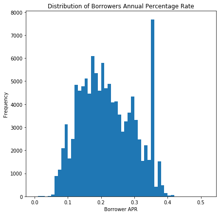

```python
plt.figure(figsize=[7, 7])
# Set bin size
bins = np.arange(0, prosper_df['BorrowerAPR'].max()+0.01, 0.01)
#plot the histogram
plt.hist(data = prosper_df, x = 'BorrowerAPR', bins = bins)
plt.xlabel('Borrower APR')
plt.title('Distribution of Borrowers Annual Percentage Rate')
plt.ylabel('Frequency');
```

### BorrowerAPR distribution observation

The distribution of the BorrowerAPR is multimodal with the highest peak between 0.35 and 0.4. What is the reason for this peak?

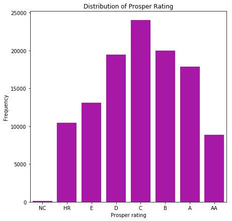

```python
#Plot a bar chart for 'ProsperRating_Combined' column
plt.figure(figsize=[7, 7])
sb.countplot(data=prosper_df, x='ProsperRating_Combined', color='m')
plt.title('Distribution of Prosper Rating')
plt.xlabel('Prosper rating')
plt.ylabel('Frequency');
```

### ProsperRating_Combined distribution observation

'C' rating has the highest frequency followed by 'B', rating 'NC' being this few is no surprise as the rating was used only in pre-2009. The plot shows that Prosper loan does not frequently rate borrowers 'AA'.

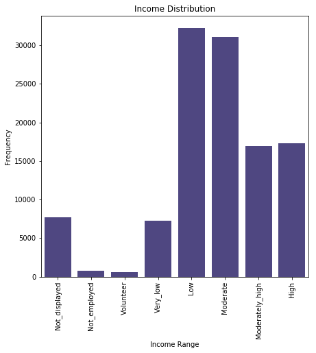

```python
#Plot a bar chart for 'IncomeRange' column
plt.figure(figsize=[7, 7])
sb.countplot(data=prosper_df, x='IncomeRange', color='darkslateblue')
plt.xlabel("Income Range")
plt.ylabel('Frequency')
plt.xticks(rotation= 90)
plt.title('Income Distribution');
```

### IncomeRange distribution observation

Low income earners have the highest frequency followed closely by Moderate income earners. This is surprising because I would think at least the Very_low income earners should have the highest frequency because the Not_employed and Volunteers may not have income to repay.

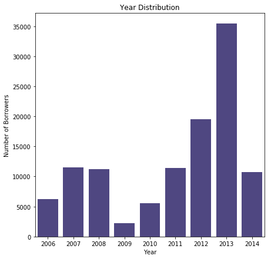

```python
#Plot a bar chart for 'Year' column
plt.figure(figsize=[7, 7])
sb.countplot(data=prosper_df, x='Year', color='darkslateblue')
plt.xlabel("Year")
plt.ylabel('Number of Borrowers')
plt.title('Year Distribution');
```

### Year distribution observation

The year distribution shows that from 2009 there was a consistent increase in borrowers with 2013 almost doubling 2012's size but 2014 has a great drop in borrowers.

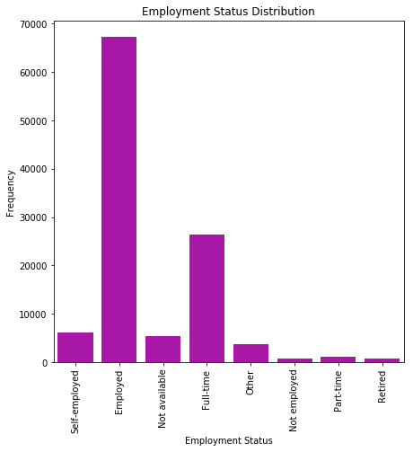

```python
#Plot a bar chart for 'EmploymentStatus' column
plt.figure(figsize=[7, 7])
sb.countplot(data=prosper_df, x='EmploymentStatus', color='m')
plt.xlabel("Employment Status")
plt.ylabel('Frequency')
plt.xticks(rotation= 90)
plt.title('Employment Status Distribution');
```

### Employment Status distribution observation

The values for the employment status are a bit confusing as there is no difference between 'Employed' and 'Full-time' and that is why I did not change Employment Status to a categorical variable as I would not not know which value should precede the other.

```python
#Percentage function
def percentage(variable):
    total= 113937
    #find the percentage and round it to 1 decimal place
    percent= round(((variable/total)*100), 1)
    percent_age = str(percent) + '%'  # convert to string and append the percentage symbol %
    print(percent_age)
```

```python
#Calculate the percentage where CurrentlyInGroup is True
percentage(prosper_df[prosper_df['CurrentlyInGroup']].count()['CurrentlyInGroup'])
```

```
11.2%
```

```python
#Calculate the percentage where CurrentlyInGroup is False
percentage(prosper_df[~prosper_df['CurrentlyInGroup']].count()['CurrentlyInGroup'])
```

```
88.8%
```

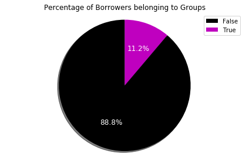

```python
#Pie chart to show the percentage of CurrentlyInGroup column
color= ("k", "m")
label=['False','True']
plt.pie(prosper_df['CurrentlyInGroup'].value_counts(), colors=color, autopct='%1.1f%%', shadow=True, startangle=90, textprops={'fontsize':12,'color':'white'})
plt.title("Percentage of Borrowers belonging to Groups")
plt.legend(label)
plt.axis('equal')
plt.tight_layout()
plt.show;
```

### CurrentlyInGroup observation

The piechart shows that 11.2% of borrowers belong to groups while 88.8% do not belong to groups.

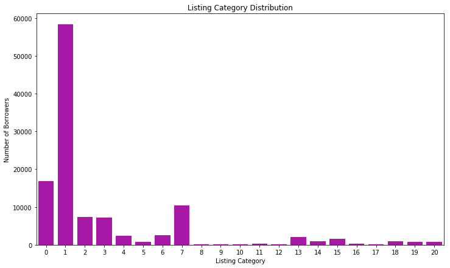

```python
#Plot a bar chart for 'ListingCategory_numeric' column
plt.figure(figsize=[12, 7])
sb.countplot(data=prosper_df, x='ListingCategory_numeric', color='m')
plt.xlabel("Listing Category")
plt.ylabel('Number of Borrowers')
plt.title('Listing Category Distribution');
```

### ListingCategory_numeric observation

Debt Consolidation (1) is the most reason for loans.

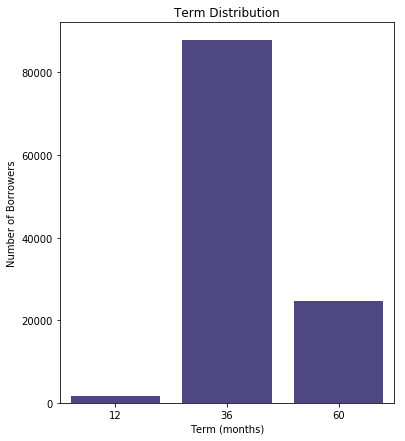

```python
#Plot a bar chart for 'Term' column
plt.figure(figsize=[6, 7])
sb.countplot(data=prosper_df, x='Term', color='darkslateblue')
plt.xlabel("Term (months)")
plt.ylabel('Number of Borrowers')
plt.title('Term Distribution');
```

### Term distribution observation

This shows that 36 months (3 years) was the most month given to borrowers to repay loans.

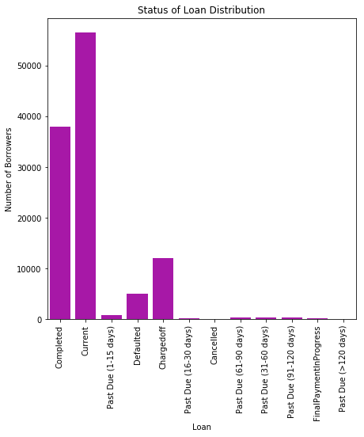

```python
#Plot a bar chart for 'Term' column
plt.figure(figsize=[7, 7])
sb.countplot(data=prosper_df, x='LoanStatus', color='m')
plt.xticks(rotation=90)
plt.xlabel("Loan")
plt.ylabel('Number of Borrowers')
plt.title('Status of Loan Distribution');
```

### LoanStatus distribution observation

The obvious loan status are 'Current', 'Completed', 'Chargedoff', 'Defaulted', and 'Past Due (1-15 days)' with current being the highest.

### Question 2: How did borrowers without prosper rating fare in the status of their loan?

```python
# select prosper rating with null values
pros_null=prosper_df.loc[(prosper_df.ProsperRating_Combined.isnull())]
pros_null
```

|  | ListingCreationDate | Term | LoanStatus | BorrowerAPR | BorrowerRate | ListingCategory_numeric | Occupation | EmploymentStatus | IsBorrowerHomeowner | CurrentlyInGroup | PublicRecordsLast10Years | BankcardUtilization | DebtToIncomeRatio | IncomeRange | IncomeVerifiable | Recommendations | Investors | ProsperRating_Combined | Year |
| --- | --- | --- | --- | --- | --- | --- | --- | --- | --- | --- | --- | --- | --- | --- | --- | --- | --- | --- | --- |
| 150 | 2008-06-12 11:59:55.217 | 36 | Completed | 0.08641 | 0.0830 | 7 | Professional | Full-time | True | False | 0.0 | 0.12 | 0.06 | Moderate | True | 0 | 290 | NaN | 2008 |
| 528 | 2009-04-28 14:08:57.100 | 36 | Completed | 0.17170 | 0.1500 | 1 | Food Service | Full-time | True | False | 0.0 | 0.16 | 0.26 | Low | True | 0 | 220 | NaN | 2009 |
| 725 | 2008-04-27 19:21:57.207 | 36 | Completed | 0.10082 | 0.0800 | 1 | Food Service Management | Full-time | False | True | 0.0 | 0.20 | NaN | Very_low | False | 1 | 120 | NaN | 2008 |
| 1977 | 2008-04-30 16:33:46.990 | 36 | Completed | 0.17291 | 0.1365 | 1 | Other | Retired | False | True | 1.0 | 0.08 | 0.11 | Low | True | 0 | 36 | NaN | 2008 |
| 3487 | 2008-06-11 16:48:13.620 | 36 | Completed | 0.16005 | 0.1385 | 2 | Executive | Full-time | False | False | 0.0 | 0.07 | 0.09 | High | True | 0 | 207 | NaN | 2008 |
| 6500 | 2008-04-21 07:36:34.787 | 36 | Completed | 0.07339 | 0.0700 | 5 | Student - College Graduate Student | Full-time | True | False | 0.0 | 0.28 | 0.25 | Low | True | 0 | 163 | NaN | 2008 |
| 6629 | 2007-12-12 09:17:58.200 | 36 | Completed | 0.20210 | 0.1800 | 2 | Administrative Assistant | Full-time | True | False | 0.0 | 0.60 | 0.19 | Very_low | True | 0 | 228 | NaN | 2007 |
| 7277 | 2008-10-16 20:58:14.297 | 36 | Completed | 0.22287 | 0.2005 | 1 | Civil Service | Full-time | False | False | 0.0 | 0.45 | 0.22 | Moderately_high | True | 0 | 196 | NaN | 2008 |
| 8602 | 2008-09-22 14:31:17.130 | 36 | Completed | 0.28777 | 0.2645 | 1 | Skilled Labor | Full-time | False | False | 0.0 | 0.70 | 0.15 | Moderate | True | 0 | 306 | NaN | 2008 |
| 9177 | 2008-04-17 11:51:19.233 | 36 | Completed | 0.10335 | 0.0825 | 7 | Analyst | Full-time | False | False | 0.0 | 0.33 | 0.03 | High | True | 0 | 150 | NaN | 2008 |
| 9508 | 2008-06-11 19:39:08.997 | 36 | Completed | 0.11649 | 0.0905 | 1 | Teacher | Self-employed | False | False | 0.0 | 0.57 | NaN | Low | False | 0 | 63 | NaN | 2008 |
| 10441 | 2008-04-21 10:56:13.547 | 36 | Completed | 0.09171 | 0.0710 | 3 | Professional | Full-time | True | False | 0.0 | 0.05 | 0.04 | High | True | 0 | 305 | NaN | 2008 |
| 14865 | 2008-08-16 04:25:34.360 | 36 | Completed | 0.23794 | 0.2001 | 6 | Other | Full-time | True | False | 1.0 | 0.84 | 0.55 | Very_low | True | 0 | 18 | NaN | 2008 |
| 16232 | 2008-09-22 16:25:17.520 | 36 | Completed | 0.17069 | 0.1490 | 6 | Retail Management | Full-time | False | False | 0.0 | 0.59 | 0.18 | Low | True | 0 | 101 | NaN | 2008 |
| 17083 | 2008-08-19 21:13:03.780 | 36 | Completed | 0.11520 | 0.0800 | 7 | Other | Part-time | False | False | 0.0 | 0.01 | NaN | Very_low | False | 0 | 49 | NaN | 2008 |
| 17189 | 2007-12-12 07:54:54.010 | 36 | Completed | 0.23200 | 0.2095 | 1 | Professional | Full-time | False | True | 0.0 | 0.54 | 0.31 | Moderate | True | 0 | 123 | NaN | 2007 |
| 17513 | 2008-09-04 09:21:00.340 | 36 | Completed | 0.20766 | 0.1830 | 5 | Professional | Full-time | False | False | 0.0 | 0.21 | 0.28 | Low | True | 0 | 97 | NaN | 2008 |
| 19813 | 2008-07-24 19:44:50.887 | 36 | Completed | 0.26247 | 0.2265 | 7 | Professional | Employed | True | False | 1.0 | 0.57 | 0.26 | Moderate | True | 0 | 110 | NaN | 2008 |
| 21414 | 2009-04-29 15:14:59.247 | 36 | Completed | 0.11094 | 0.0900 | 7 | Police Officer/Correction Officer | Full-time | False | True | 0.0 | 0.19 | 0.22 | Moderate | True | 1 | 166 | NaN | 2009 |
| 22169 | 2008-04-06 09:33:38.223 | 36 | Completed | 0.28902 | 0.2500 | 1 | Other | Employed | False | False | 0.0 | 0.79 | 0.20 | Moderate | True | 0 | 22 | NaN | 2008 |
| 22756 | 2008-09-08 11:09:00.380 | 36 | Completed | 0.07790 | 0.0745 | 3 | Professional | Full-time | True | False | 0.0 | 0.03 | 0.18 | Moderately_high | True | 0 | 117 | NaN | 2008 |
| 22838 | 2008-01-04 08:51:03.217 | 36 | Completed | 0.33393 | 0.3100 | 7 | Administrative Assistant | Full-time | False | False | 2.0 | 0.22 | 0.36 | Low | True | 0 | 93 | NaN | 2008 |
| 23200 | 2008-08-20 18:56:35.673 | 36 | Completed | 0.07639 | 0.0730 | 2 | Computer Programmer | Full-time | True | False | 0.0 | 0.09 | 0.03 | Moderately_high | True | 0 | 154 | NaN | 2008 |
| 26879 | 2008-05-02 14:20:48.970 | 36 | Completed | 0.13524 | 0.1140 | 1 | Administrative Assistant | Full-time | False | False | 0.0 | 0.43 | 0.14 | Moderate | True | 1 | 370 | NaN | 2008 |
| 27698 | 2008-01-24 15:24:40.910 | 36 | Completed | 0.11296 | 0.0920 | 2 | Analyst | Full-time | True | False | 0.0 | 0.55 | 0.38 | Moderate | True | 0 | 233 | NaN | 2008 |
| 28750 | 2008-09-14 10:04:39.650 | 36 | Completed | 0.38723 | 0.3500 | 2 | Bus Driver | Full-time | True | True | 0.0 | 0.00 | 0.37 | Very_low | True | 0 | 21 | NaN | 2008 |
| 29309 | 2009-05-06 23:55:16.543 | 36 | Completed | 0.12279 | 0.1017 | 1 | Other | Full-time | False | False | 0.0 | 0.17 | 0.21 | Moderate | True | 0 | 239 | NaN | 2009 |
| 29667 | 2008-09-09 08:34:49.643 | 36 | Completed | 0.06207 | 0.0587 | 1 | Other | Full-time | True | False | 0.0 | 0.38 | 0.04 | Low | True | 1 | 79 | NaN | 2008 |
| 30021 | 2008-08-13 11:14:22.690 | 36 | Completed | 0.22287 | 0.2005 | 1 | Computer Programmer | Full-time | False | False | 0.0 | 0.73 | 0.14 | High | True | 0 | 142 | NaN | 2008 |
| 31378 | 2008-06-18 18:52:56.473 | 36 | Completed | 0.10448 | 0.0695 | 1 | Sales - Retail | Part-time | False | False | 0.0 | 0.05 | 0.32 | Low | True | 0 | 80 | NaN | 2008 |
| ... | ... | ... | ... | ... | ... | ... | ... | ... | ... | ... | ... | ... | ... | ... | ... | ... | ... | ... | ... |
| 85666 | 2008-08-19 19:54:25.720 | 36 | Completed | 0.13745 | 0.1138 | 7 | Civil Service | Full-time | True | True | 1.0 | 0.20 | 0.09 | Moderately_high | True | 0 | 22 | NaN | 2008 |
| 86930 | 2008-03-07 10:34:39.313 | 36 | Completed | 0.38723 | 0.3500 | 3 | Professional | Full-time | True | True | 1.0 | 0.00 | 0.13 | High | True | 0 | 106 | NaN | 2008 |
| 87662 | 2009-05-04 11:00:03.903 | 36 | Completed | 0.16107 | 0.1395 | 3 | Civil Service | Full-time | True | False | 0.0 | 0.66 | 0.29 | Moderate | True | 0 | 185 | NaN | 2009 |
| 87790 | 2007-12-16 21:13:56.717 | 36 | Completed | 0.17018 | 0.1485 | 1 | Professional | Full-time | False | False | 0.0 | 0.53 | 0.21 | Moderate | True | 0 | 358 | NaN | 2007 |
| 88160 | 2008-04-30 10:26:32.553 | 36 | Completed | 0.16157 | 0.1400 | 1 | Accountant/CPA | Employed | True | False | 0.0 | 0.49 | 0.20 | Moderate | True | 0 | 249 | NaN | 2008 |
| 88439 | 2008-05-07 03:54:50.723 | 36 | Completed | 0.38058 | 0.3435 | 7 | Engineer - Mechanical | Full-time | True | False | 0.0 | 0.96 | 0.32 | Moderate | True | 0 | 46 | NaN | 2008 |
| 89408 | 2007-12-06 11:40:53.200 | 36 | Completed | 0.29831 | 0.2749 | 7 | Waiter/Waitress | Full-time | False | False | 0.0 | 0.00 | NaN | Low | False | 0 | 48 | NaN | 2007 |
| 90162 | 2008-05-09 11:28:42.250 | 36 | Completed | 0.11094 | 0.0900 | 1 | Other | Full-time | True | False | 0.0 | 0.30 | 0.24 | Low | True | 0 | 140 | NaN | 2008 |
| 90520 | 2008-09-15 15:55:30.363 | 36 | Completed | 0.33097 | 0.2950 | 1 | Pilot - Private/Commercial | Full-time | True | False | 0.0 | 0.54 | 0.17 | High | True | 0 | 138 | NaN | 2008 |
| 91915 | 2008-04-22 06:31:34.213 | 36 | Chargedoff | 0.11074 | 0.0898 | 1 | Other | Full-time | True | False | 0.0 | 0.30 | 0.22 | Moderate | True | 0 | 224 | NaN | 2008 |
| 92340 | 2007-12-28 11:13:40.403 | 36 | Completed | 0.07539 | 0.0720 | 1 | Computer Programmer | Full-time | True | False | 0.0 | 0.15 | 0.09 | Moderately_high | True | 0 | 196 | NaN | 2007 |
| 92465 | 2009-04-28 06:08:45.240 | 36 | Completed | 0.28320 | 0.2600 | 1 | Other | Full-time | False | False | 0.0 | 0.58 | NaN | Low | False | 1 | 289 | NaN | 2009 |
| 93681 | 2008-08-26 07:11:20.117 | 36 | Completed | 0.25024 | 0.2275 | 1 | Engineer - Mechanical | Full-time | True | False | 0.0 | 0.44 | 0.36 | Moderate | True | 0 | 551 | NaN | 2008 |
| 93928 | 2009-05-03 09:42:54.930 | 36 | Completed | 0.19095 | 0.1690 | 2 | Sales - Retail | Full-time | True | False | 1.0 | 0.11 | 0.27 | Moderate | True | 0 | 121 | NaN | 2009 |
| 94247 | 2008-10-16 11:08:52.870 | 36 | Defaulted | 0.22338 | 0.2010 | 6 | Nurse (RN) | Full-time | False | False | 0.0 | 0.08 | 0.16 | Moderate | True | 0 | 91 | NaN | 2008 |
| 98327 | 2007-11-12 10:34:56.957 | 36 | Completed | 0.17018 | 0.1485 | 1 | Computer Programmer | Full-time | True | False | 0.0 | 0.34 | 0.09 | High | True | 0 | 400 | NaN | 2007 |
| 98946 | 2008-04-22 12:14:56.703 | 36 | Completed | 0.11296 | 0.0920 | 1 | Other | Full-time | False | True | 0.0 | 0.50 | 0.17 | Low | True | 2 | 226 | NaN | 2008 |
| 101965 | 2008-04-23 12:23:41.433 | 36 | Completed | 0.20767 | 0.1855 | 3 | Food Service Management | Full-time | False | False | 0.0 | 0.84 | 0.23 | Low | True | 0 | 183 | NaN | 2008 |
| 102456 | 2009-05-02 23:09:38.770 | 36 | Completed | 0.12663 | 0.1055 | 1 | Scientist | Full-time | False | False | 0.0 | 0.45 | 0.18 | High | True | 0 | 141 | NaN | 2009 |
| 103577 | 2008-07-29 17:49:02.663 | 36 | Completed | 0.18183 | 0.1600 | 3 | Sales - Retail | Full-time | True | False | 0.0 | 0.58 | 0.30 | Low | True | 0 | 161 | NaN | 2008 |
| 103617 | 2008-07-01 07:13:02.713 | 36 | Completed | 0.22135 | 0.1990 | 6 | Other | Full-time | False | False | 0.0 | 0.50 | 0.20 | Moderate | True | 0 | 59 | NaN | 2008 |
| 104665 | 2008-10-07 21:55:11.097 | 36 | Completed | 0.07439 | 0.0710 | 1 | Computer Programmer | Full-time | False | True | 0.0 | 0.44 | 0.23 | Moderately_high | True | 0 | 238 | NaN | 2008 |
| 104963 | 2008-02-24 08:37:06.950 | 36 | Completed | 0.07830 | 0.0749 | 1 | Other | Employed | True | False | 0.0 | 0.21 | 0.03 | Moderate | True | 0 | 112 | NaN | 2008 |
| 105276 | 2008-07-29 13:25:05.437 | 36 | Chargedoff | 0.13220 | 0.1110 | 1 | Realtor | Self-employed | False | False | 0.0 | 0.45 | NaN | Low | False | 0 | 37 | NaN | 2008 |
| 107371 | 2008-06-30 09:27:28.380 | 36 | Completed | 0.09069 | 0.0700 | 1 | Fireman | Full-time | False | False | 0.0 | 0.74 | 0.20 | Moderately_high | True | 0 | 106 | NaN | 2008 |
| 107379 | 2008-01-10 14:47:48.627 | 36 | Completed | 0.31633 | 0.2900 | 6 | Engineer - Mechanical | Full-time | False | False | 0.0 | 0.18 | 0.17 | Moderate | True | 1 | 39 | NaN | 2008 |
| 109682 | 2009-05-02 11:05:29.940 | 36 | Completed | 0.11418 | 0.0790 | 7 | Skilled Labor | Full-time | True | True | 1.0 | 0.00 | 0.15 | Low | True | 0 | 36 | NaN | 2009 |
| 112118 | 2007-10-25 16:34:33.430 | 36 | Completed | 0.09221 | 0.0715 | 3 | Other | Retired | True | False | 0.0 | 0.43 | 0.36 | Moderate | True | 0 | 123 | NaN | 2007 |
| 112763 | 2007-09-22 13:15:28.047 | 36 | Completed | 0.09932 | 0.0715 | 3 | Professional | Full-time | True | False | 0.0 | 0.00 | 0.02 | Moderately_high | True | 0 | 43 | NaN | 2007 |
| 113403 | 2008-04-16 08:42:10.580 | 36 | Completed | 0.25786 | 0.2000 | 1 | Truck Driver | Employed | False | False | 0.0 | 0.68 | 0.03 | Moderate | True | 0 | 98 | NaN | 2008 |

131 rows × 19 columns

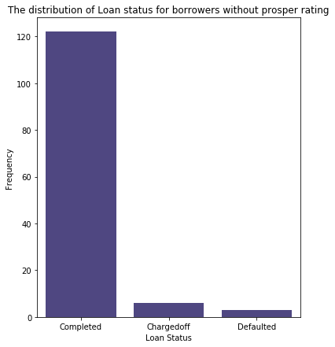

```python
#Bar chart of null prosper rating on loan status
plt.figure(figsize=(6,7))
sb.countplot(data = pros_null, x = 'LoanStatus', color= 'darkslateblue')
plt.title('The distribution of Loan status for borrowers without prosper rating')
plt.ylabel('Frequency')
plt.xlabel('Loan Status');
```

### Observation after visualisation

This shows that despite not having a prosper rating, majority of these borrowers completed their loan payment.

### Discuss the distribution(s) of your variable(s) of interest. Were there any unusual points? Did you need to perform any transformations?

> The BorrowerAPR variable contained null values so I had to drop the nulls to be able to plot a histogram of the variable. The distribution showed that the BorrowerAPR is multimodal with its highest peak between 0.35 and 0.4.

### Of the features you investigated, were there any unusual distributions? Did you perform any operations on the data to tidy, adjust, or change the form of the data? If so, why did you do this?

> I had already tidied CreditGrade and ProsperRating_Alpha columns to form the ProsperRating_Combined column because using either of them will not properly depict the information as only CreditGrade has ratings for pre-2009 and ProsperRating_Alpha has ratings for post-2009. Merging them allowed me see the distribution of Prosper's rating at a glance. I extracted the Year column after changing the datatype of ListingCreationDate column from a string to timestamp to explore the distribution of Year. I also selected borrowers without a prosper rating to see how they fared in their loan status.

## Bivariate Exploration

### Question 3: Does prosper rating affect Borrower's Annual percentage rate?

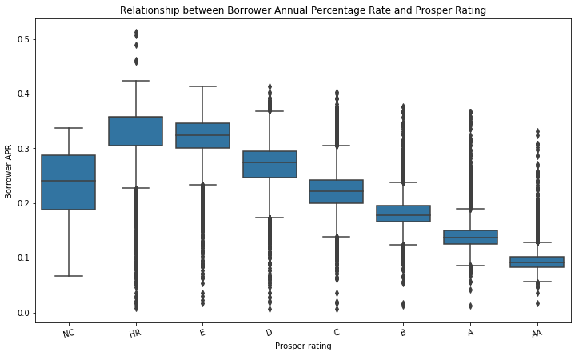

```python
#Choose a base color
base_color = sb.color_palette()[0]

plt.figure(figsize=(12,7))
sb.boxplot(data=prosper_df, x='ProsperRating_Combined', y='BorrowerAPR', color=base_color)
plt.xticks(rotation=15)
plt.title('Relationship between Borrower Annual Percentage Rate and Prosper Rating')
plt.ylabel('Borrower APR')
plt.xlabel('Prosper rating');
```

### Observation after visualisation

Apart from the NC grade which was discontinued after July 2009, the box plot shows that the higher a borrower's prosper rating is, the lower the BorrowerAPR given to the borrower. The median value decreases as the prosper rating increases.

### Question 4: Is BorrowerAPR the reason for the distribution observed in years 2013 and 2014?

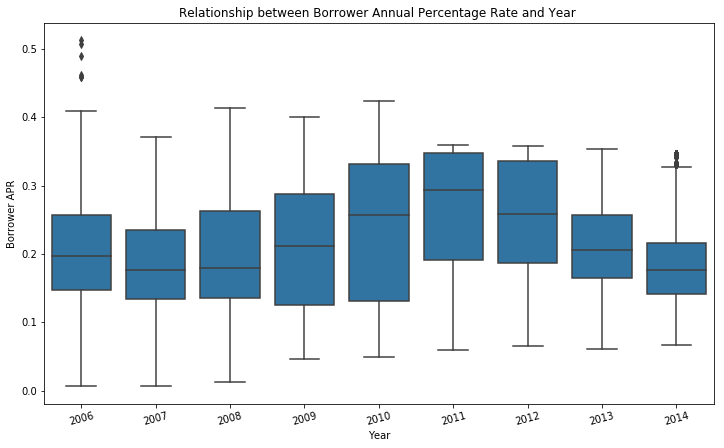

```python
#Relationship between Borrower Annual Percentage Rate and Year
plt.figure(figsize=(12,7))
sb.boxplot(data=prosper_df, x='Year', y='BorrowerAPR', color=base_color)
plt.xticks(rotation=15)
plt.title('Relationship between Borrower Annual Percentage Rate and Year ')
plt.ylabel('Borrower APR')
plt.xlabel('Year');
```

### Observation after visualisation

The bar chart of Year in the Univariate section showed that from 2009 till 2013 there was steady increase in borrowers till 2014 experienced a great drop. This plot shows an increase in BorrowerAPR from 2009 to 2011 and a decrease from 2012 to 2014. A further decrease in 2014 should have inceased the number of borrwers like in 2013 but it did not have any effect.

### Question 5: Does income range influence borrowerAPR?

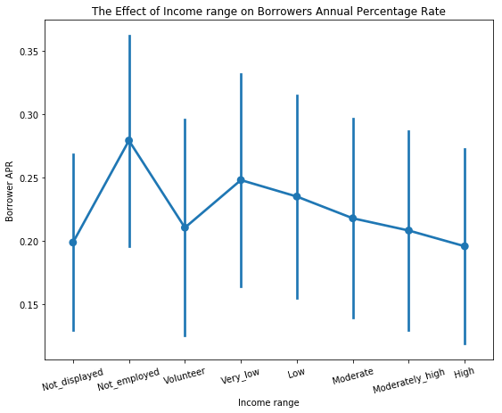

```python
#plot a pointplot of IncomeRange against BorrowerAPR
plt.figure(figsize=(9,7))
sb.pointplot(data=prosper_df, x='IncomeRange', y='BorrowerAPR', color=base_color, ci='sd')
plt.xticks(rotation=15)
plt.title('The Effect of Income range on Borrowers Annual Percentage Rate')
plt.ylabel('Borrower APR')
plt.xlabel('Income range');
```

### Observation after visualisation

Income range influences borrowerAPR. The borrowerAPR decreased as income range increased from Very_low to High (around 0.25-0.18) but this plot shows something interesting, though the frequency of Not_displayed was almost 10 times more than the frequency of Not_employed(in the Univariate plot of Income range), lower borrowerAPR was given to those who didn't display their income and those who earned $0 (Volunteers) than the Not_employed.

### Question 6: What is the relationship between BorrowerAPR and DebtToIncomeRatio?

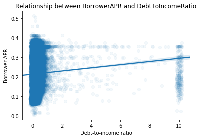

```python
#Regplot of DebtToIncomeRatio against BorrowerAPR
sb.regplot(data =prosper_df, x = 'DebtToIncomeRatio', y = 'BorrowerAPR', truncate=False, x_jitter=0.2,
           scatter_kws={'alpha':1/20})
plt.xlabel('Debt-to-income ratio')
plt.ylabel('Borrower APR')
plt.title('Relationship between BorrowerAPR and DebtToIncomeRatio');
```

### Observation after visualisation

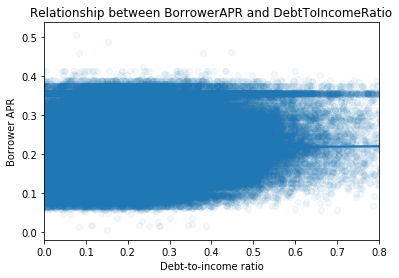

```python
# I will zoom in to be sure of the data points between 0 and 1.8 on the x-axis.
#Zoom in by setting the xlim
sb.regplot(data =prosper_df, x = 'DebtToIncomeRatio', y = 'BorrowerAPR', truncate=False, x_jitter=0.2,
           scatter_kws={'alpha':1/20})
plt.xlabel('Debt-to-income ratio')
plt.ylabel('Borrower APR')
plt.title('Relationship between BorrowerAPR and DebtToIncomeRatio')
plt.xlim(0.0,0.8);
```

### Question 7: What is the distribution of Prosper rating with respect to Loan status?

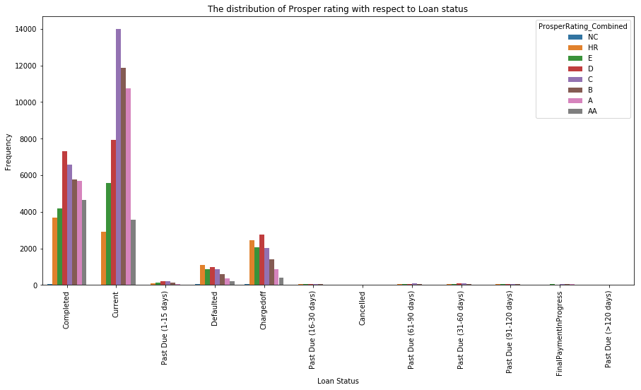

```python
#plot a clustered bar chart for 'ProsperRating_Combined' and 'LoanStatus' using the loan_imp_sta df
plt.figure(figsize=(15,7))
sb.countplot(data = prosper_df, x = 'LoanStatus', hue = 'ProsperRating_Combined')
plt.title('The distribution of Prosper rating with respect to Loan status')
plt.ylabel('Frequency')
plt.xlabel('Loan Status')
plt.xticks(rotation= 90);
```

### Observation after visualisation

To view them better, extract only the first 5 LoanStatus values as the rest have few values.

```python
#Get the loan status with high values only as the other values are too low
important_status=['Current', 'Completed', 'Chargedoff', 'Defaulted', 'Past Due (1-15 days)']
#display only the important status
loan_imp_sta= prosper_df.query('LoanStatus in @important_status')
loan_imp_sta.head()
```

|  | ListingCreationDate | Term | LoanStatus | BorrowerAPR | BorrowerRate | ListingCategory_numeric | Occupation | EmploymentStatus | IsBorrowerHomeowner | CurrentlyInGroup | PublicRecordsLast10Years | BankcardUtilization | DebtToIncomeRatio | IncomeRange | IncomeVerifiable | Recommendations | Investors | ProsperRating_Combined | Year |
| --- | --- | --- | --- | --- | --- | --- | --- | --- | --- | --- | --- | --- | --- | --- | --- | --- | --- | --- | --- |
| 0 | 2007-08-26 19:09:29.263 | 36 | Completed | 0.16516 | 0.1580 | 0 | Other | Self-employed | True | True | 0.0 | 0.00 | 0.17 | Low | True | 0 | 258 | C | 2007 |
| 1 | 2014-02-27 08:28:07.900 | 36 | Current | 0.12016 | 0.0920 | 2 | Professional | Employed | False | False | 1.0 | 0.21 | 0.18 | Moderate | True | 0 | 1 | A | 2014 |
| 2 | 2007-01-05 15:00:47.090 | 36 | Completed | 0.28269 | 0.2750 | 0 | Other | Not available | False | True | 0.0 | NaN | 0.06 | Not_displayed | True | 0 | 41 | HR | 2007 |
| 3 | 2012-10-22 11:02:35.010 | 36 | Current | 0.12528 | 0.0974 | 16 | Skilled Labor | Employed | True | False | 0.0 | 0.04 | 0.15 | Low | True | 0 | 158 | A | 2012 |
| 4 | 2013-09-14 18:38:39.097 | 36 | Current | 0.24614 | 0.2085 | 2 | Executive | Employed | True | False | 0.0 | 0.81 | 0.26 | High | True | 0 | 20 | D | 2013 |

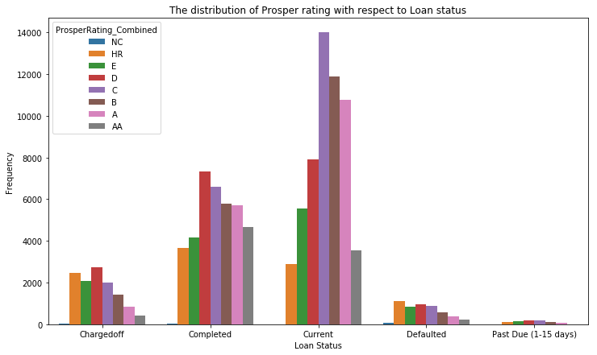

```python
#plot a clustered bar chart for 'ProsperRating_Combined' and 'LoanStatus' using the important status(loan_imp_sta df)
plt.figure(figsize=(12,7))
#order the values for loan status
cat_order = ['Chargedoff', 'Completed', 'Current', 'Defaulted', 'Past Due (1-15 days)']
sb.countplot(data = loan_imp_sta, x = 'LoanStatus', hue = 'ProsperRating_Combined', order= cat_order)
plt.title('The distribution of Prosper rating with respect to Loan status')
plt.ylabel('Frequency')
plt.xlabel('Loan Status');
```

### Observation after visualisation

Borrowers with a 'D' prosper rating completed their loan compared to others and 'NC' had the least Defaulted value in this plot but this is not a true representation as some ratings have more values than the others. So I will calculate the proportion of each Prosper rating before plotting the graph to determine the actual rating that has the highest completed and least defaulted loan status value.

```python
# Total counts for each prosper rating agoup
pros_count = loan_imp_sta.groupby('ProsperRating_Combined').count()['Term']
pros_count
```

```
ProsperRating_Combined
NC      140
HR    10227
E     12812
D     19131
C     23666
B     19760
A     17738
AA     8836
Name: Term, dtype: int64
```

```python
#The  values of ProsperRating_Combined column with respect to LoanStatus column (for only the important loan status values)
pros_grp =loan_imp_sta.groupby(['ProsperRating_Combined','LoanStatus']).count()['Term']
pros_grp
```

```
ProsperRating_Combined  LoanStatus
NC                      Chargedoff                 35.0
                        Completed                  41.0
                        Current                     NaN
                        Defaulted                  64.0
                        Past Due (1-15 days)        NaN
HR                      Chargedoff               2457.0
                        Completed                3671.0
                        Current                  2900.0
                        Defaulted                1100.0
                        Past Due (1-15 days)       99.0
E                       Chargedoff               2077.0
                        Completed                4183.0
                        Current                  5558.0
                        Defaulted                 858.0
                        Past Due (1-15 days)      136.0
D                       Chargedoff               2738.0
                        Completed                7317.0
                        Current                  7920.0
                        Defaulted                 966.0
                        Past Due (1-15 days)      190.0
C                       Chargedoff               2016.0
                        Completed                6583.0
                        Current                 14001.0
                        Defaulted                 863.0
                        Past Due (1-15 days)      203.0
B                       Chargedoff               1409.0
                        Completed                5770.0
                        Current                 11891.0
                        Defaulted                 581.0
                        Past Due (1-15 days)      109.0
A                       Chargedoff                852.0
                        Completed                5707.0
                        Current                 10755.0
                        Defaulted                 362.0
                        Past Due (1-15 days)       62.0
AA                      Chargedoff                402.0
                        Completed                4655.0
                        Current                  3551.0
                        Defaulted                 221.0
                        Past Due (1-15 days)        7.0
Name: Term, dtype: float64
```

```python
# The proportion of 'NC' rating with respect to LoanStatus
NC_loan = pros_grp['NC'] / pros_count['NC']
NC_loan
```

```
LoanStatus
Chargedoff              0.250000
Completed               0.292857
Current                      NaN
Defaulted               0.457143
Past Due (1-15 days)         NaN
Name: Term, dtype: float64
```

```python
# The proportion of 'HR' rating with respect to LoanStatus
HR_loan = pros_grp['HR'] / pros_count['HR']
HR_loan
```

```
LoanStatus
Chargedoff              0.240246
Completed               0.358952
Current                 0.283563
Defaulted               0.107558
Past Due (1-15 days)    0.009680
Name: Term, dtype: float64
```

```python
# The proportion of 'E' rating with respect to LoanStatus
E_loan = pros_grp['E'] / pros_count['E']
E_loan
```

```
LoanStatus
Chargedoff              0.162114
Completed               0.326491
Current                 0.433812
Defaulted               0.066968
Past Due (1-15 days)    0.010615
Name: Term, dtype: float64
```

```python
# The proportion of 'D' rating with respect to LoanStatus
D_loan = pros_grp['D'] / pros_count['D']
D_loan
```

```
LoanStatus
Chargedoff              0.143118
Completed               0.382468
Current                 0.413988
Defaulted               0.050494
Past Due (1-15 days)    0.009932
Name: Term, dtype: float64
```

```python
# The proportion of 'C' rating with respect to LoanStatus
C_loan = pros_grp['C'] / pros_count['C']
C_loan
```

```
LoanStatus
Chargedoff              0.085185
Completed               0.278163
Current                 0.591608
Defaulted               0.036466
Past Due (1-15 days)    0.008578
Name: Term, dtype: float64
```

```python
# The proportion of 'B' rating with respect to LoanStatus
B_loan = pros_grp['B'] / pros_count['B']
B_loan
```

```
LoanStatus
Chargedoff              0.071306
Completed               0.292004
Current                 0.601771
Defaulted               0.029403
Past Due (1-15 days)    0.005516
Name: Term, dtype: float64
```

```python
# The proportion of 'A' rating with respect to LoanStatus
A_loan = pros_grp['A'] / pros_count['A']
A_loan
```

```
LoanStatus
Chargedoff              0.048032
Completed               0.321739
Current                 0.606325
Defaulted               0.020408
Past Due (1-15 days)    0.003495
Name: Term, dtype: float64
```

```python
# The proportion of 'AA' rating with respect to LoanStatus
AA_loan = pros_grp['AA'] / pros_count['AA']
AA_loan
```

```
LoanStatus
Chargedoff              0.045496
Completed               0.526822
Current                 0.401879
Defaulted               0.025011
Past Due (1-15 days)    0.000792
Name: Term, dtype: float64
```

```python
indx = np.arange(len(AA_loan))  # the x locations for the groups
```

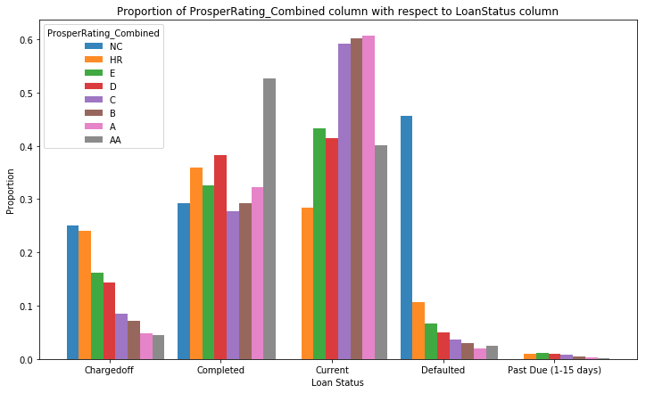

```python
# plot the bars
plt.figure(figsize=(12,7))
width1 = 0.11
blue_bars = plt.bar(indx, NC_loan, width1,  alpha=.9, label='NC')
yel_bars = plt.bar(indx + width1, HR_loan, width1, alpha=.9, label='HR')
green_bars = plt.bar(indx + width1*2, E_loan, width1, alpha=.9, label='E')
red_bars = plt.bar(indx + width1*3, D_loan, width1, alpha=.9, label='D')
pur_bars = plt.bar(indx + width1*4, C_loan, width1, alpha=.9, label='C')
brown_bars = plt.bar(indx + width1*5, B_loan, width1, alpha=.9, label='B')
pink_bars = plt.bar(indx + width1*6, A_loan, width1, alpha=.9, label='A')
gray_bars = plt.bar(indx + width1*7, AA_loan, width1, alpha=.9, label='AA')

# title and labels
plt.ylabel('Proportion')
plt.xlabel('Loan Status')
plt.title('Proportion of ProsperRating_Combined column with respect to LoanStatus column')
locations = indx + width1*3
labels = ['Chargedoff', 'Completed', 'Current', 'Defaulted', 'Past Due (1-15 days)']

plt.xticks(locations, labels)
plt.legend(title='ProsperRating_Combined');
```

### Observation after visualisation

This shows that the 'AA' prosper rating group has the highest value for 'Completed' loan status and the 'A' rating has the least value for 'Defaulted' loan status as oppossed to having 'D' and 'NC' respectively when proportions were not considered.

### Question 8: What was the borrowerAPR of borrowers without prosper rating?

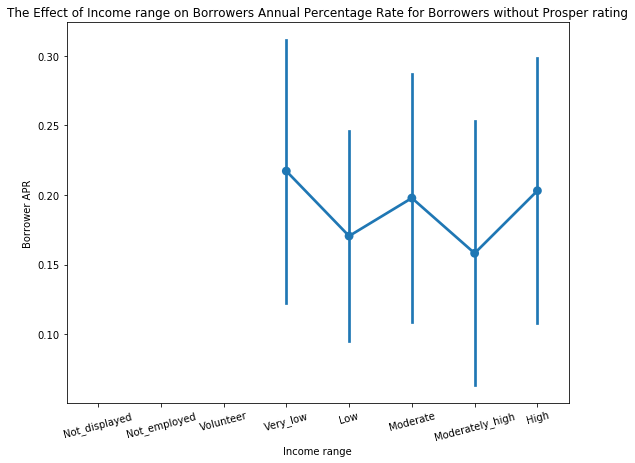

```python
#Use income range of borrowers with null prosperrating_combined value to check their borrowerAPR
plt.figure(figsize=(9,7))
sb.pointplot(data=pros_null, x='IncomeRange', y='BorrowerAPR', color=base_color, ci='sd')
plt.xticks(rotation=15)
plt.title('The Effect of Income range on Borrowers Annual Percentage Rate for Borrowers without Prosper rating')
plt.ylabel('Borrower APR')
plt.xlabel('Income range');
```

### Observation after visualisation

When I plottted Income range against BorrowerAPR I had noticed a consistent decrease in BorrowerAPR as Income increased from Very_low to High but that is not the same for people without Proser Rating as shown in this plot which has a sequence of high-to-low. I have also noticed that the BorrowerAPR for people without prosper rating are lower (around 0.16 and 0.23) for Very_low to High income range. They got low borrowerAPR despite not having prosper rating.

### Question 9: What kind of Terms were given to borrowers based on their Prosper rating?

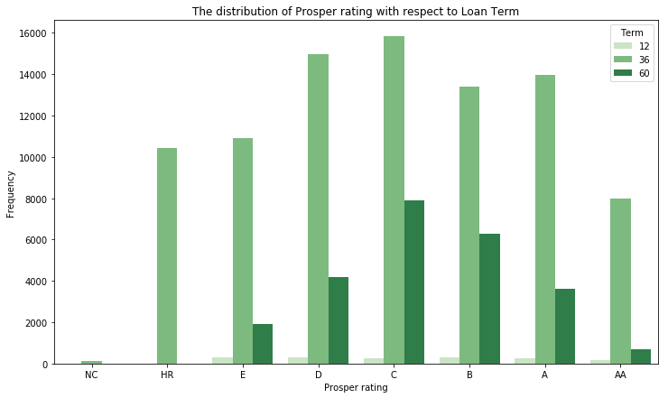

```python
#plot a clustered bar chart for 'ProsperRating_Combined' and 'LoanStatus' using the important status(loan_imp_sta df)
plt.figure(figsize=(12,7))
sb.countplot(data = prosper_df, x = 'ProsperRating_Combined', hue = 'Term', palette = 'Greens')
plt.title('The distribution of Prosper rating with respect to Loan Term')
plt.ylabel('Frequency')
plt.xlabel('Prosper rating');
```

### Observation after visualisation

Only 36 months (3 years) terms were given to NC and HR borrowers.

### Question 10: Does Debt-to-income ratio have an effect on borrowers' loan status?

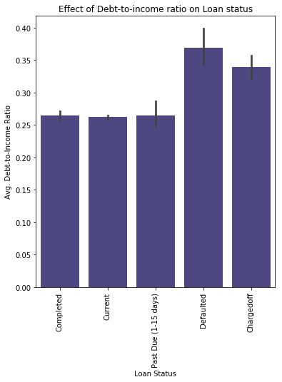

```python
#plot a bar plot for 'LoanStatus' and 'DebtToIncomeRatio' using the important status(loan_imp_sta df)
plt.figure(figsize=(6,7))
sb.barplot(data=loan_imp_sta, x='LoanStatus', y='DebtToIncomeRatio', color='darkslateblue')
plt.title('Effect of Debt-to-income ratio on Loan status')
plt.xticks(rotation=90)
plt.ylabel('Avg. Debt-to-Income Ratio')
plt.xlabel('Loan Status');
```

### Observation after visualisation

Borrowers who stopped paying(defaulted) and the ones who were written off as a loss(chargedoff) have high debt-to-income ratios with the defaulted being the highest.

### Question 11: What is the relationship between ProsperRating_Combined and DebtToIncomeRatio?

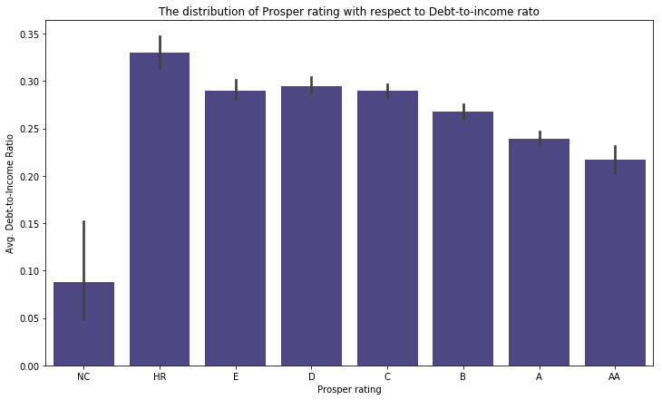

```python
#plot a barplot for 'ProsperRating_Combined' and 'DebtToIncomeRatio'
plt.figure(figsize=(12,7))
sb.barplot(data=prosper_df, x='ProsperRating_Combined', y='DebtToIncomeRatio', color='darkslateblue')
plt.title('The distribution of Prosper rating with respect to Debt-to-income rato')
plt.ylabel('Avg. Debt-to-Income Ratio')
plt.xlabel('Prosper rating');
```

### Observation after visualisation

Excluding the 'NC' rating which was discontinued after 2009, the DebtToIncomeRatio shows a weak negative correlation to ProsperRating_Coombined.

### Question 12: Do more investors go to high income earners?

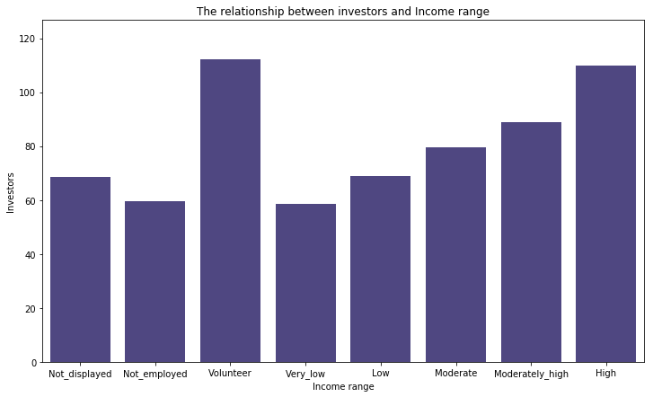

```python
#plot a clustered bar chart for 'IncomeRange' and 'Investors'
plt.figure(figsize=(12,7))
sb.barplot(data = prosper_df, x = 'IncomeRange', y = 'Investors', color='darkslateblue', errwidth=0)
plt.title('The relationship between investors and Income range')
plt.ylabel('Investors')
plt.xlabel('Income range');
```

### Observation after visualisation

Volunteers (borrowers with $0 income range) surprisingly have the highest number of investors. The consistent increase of investors from Very_low to High income range is expected.

### Talk about some of the relationships you observed in this part of the investigation. How did the feature(s) of interest vary with other features in the dataset?

> The consistent increase in year from 2009 to 2013 and the sudden decrease in year 2014 in the univariate plot for Year was explored to determine if BorrowerAPR influenced it. In the bivariate plot of Year against BorrowerAPR there was a decrease in BorrowerAPR only from 2012 to 2014 so lower BorrowerAPR was not the main reason for the increase in loans gotten from year 2009 to 2013 nor was it the reason for the drop in 2014 since lower borrowerAPR should have increased the number of loans as in the case of 2013. Further exploration would be carried out on this.

### Did you observe any interesting relationships between the other features (not the main feature(s) of interest)?

> There was a weak negative correlation between ProsperRating_Combined and DebtToIncomeRatio. There was a consistent increase in the number of investors from Very_low to High income range.

## Multivariate Exploration

### Question 13: What was the reason for the distribution observed in years 2013 and 2014?

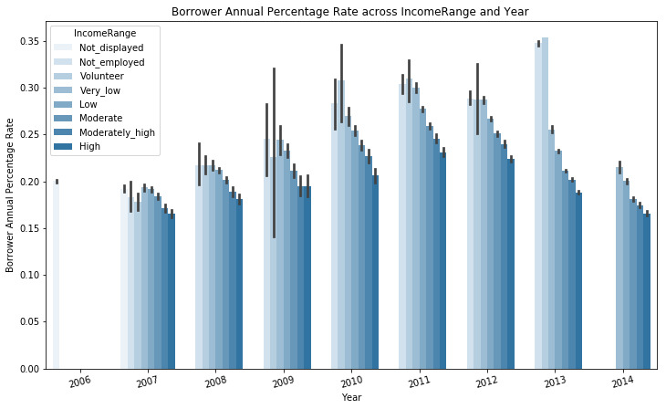

```python
#barplot of Year, BorrowerAPR, and IncomeRange
plt.figure(figsize=(12,7))
sb.barplot(data=prosper_df, x='Year', y='BorrowerAPR', hue= 'IncomeRange', color=base_color)
plt.xticks(rotation=15)
plt.title('Borrower Annual Percentage Rate across IncomeRange and Year ')
plt.ylabel('Borrower Annual Percentage Rate')
plt.xlabel('Year');
```

### Observation after visualisation

This plot shows the reason why 2013 size increased so much as the 'Not_displayed' and 'Not_employed' income range are so high and also shows that no records of 'Not_displayed', 'Not_employed', and 'Volunteer' income range in 2014 is the reason for a great drop in 2014 (year 2014 has only 5 groups).

### Question 14: Does being a group member influence BorrowerAPR for borrowers without ProsperRating_Combined value?

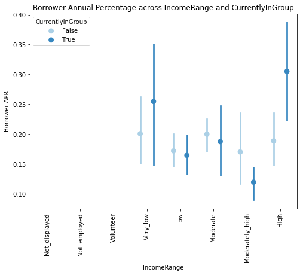

```python
#pointplot for IncomeRange, BorrowerAPR, and CurrentlyInGroup
fig = plt.figure(figsize = [8,6])
ax = sb.pointplot(data = pros_null, x='IncomeRange', y='BorrowerAPR', hue = 'CurrentlyInGroup',
           palette = 'Blues', linestyles = '', dodge = 0.4)
plt.title('Borrower Annual Percentage across IncomeRange and CurrentlyInGroup')
plt.ylabel('Borrower APR')
ax.set_yticklabels([],minor = True)
plt.xticks(rotation=90)
plt.show();
```

### Observation after visualisation

Being in a group does not have any effect as those in groups had higher borrowerAPR values in Very_low and High income range.

### Question 15: What is the effect of Term on BorrowerAPR and ProsperRating_Combined?

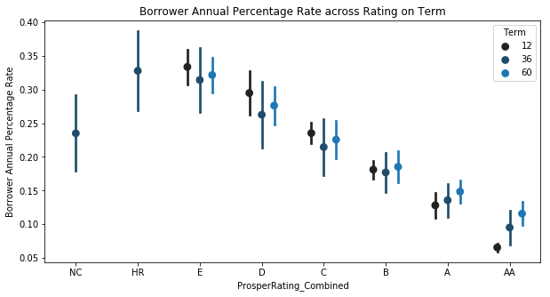

```python
#pointplot of ProsperRating_Combined, BorrowerAPR, and Term
fig = plt.figure(figsize = [10,5])
ax = sb.pointplot(data = prosper_df, x = 'ProsperRating_Combined', y = 'BorrowerAPR', hue = 'Term',color = base_color, linestyles = '', dodge = 0.4, ci='sd')
plt.title('Borrower Annual Percentage Rate across Rating on Term')
plt.ylabel('Borrower Annual Percentage Rate')
ax.set_yticklabels([],minor = True);
```

### Observation after visualisation

Only 36 months term loans were given to NC and HR borrowers. 36 months Term loans attracted lower BorrowerAPR than 60 months Term loans.

### Question 16: What is the relationship of Borrower Annual Percentage Rate across ProsperRating_Combined and IncomeRange?

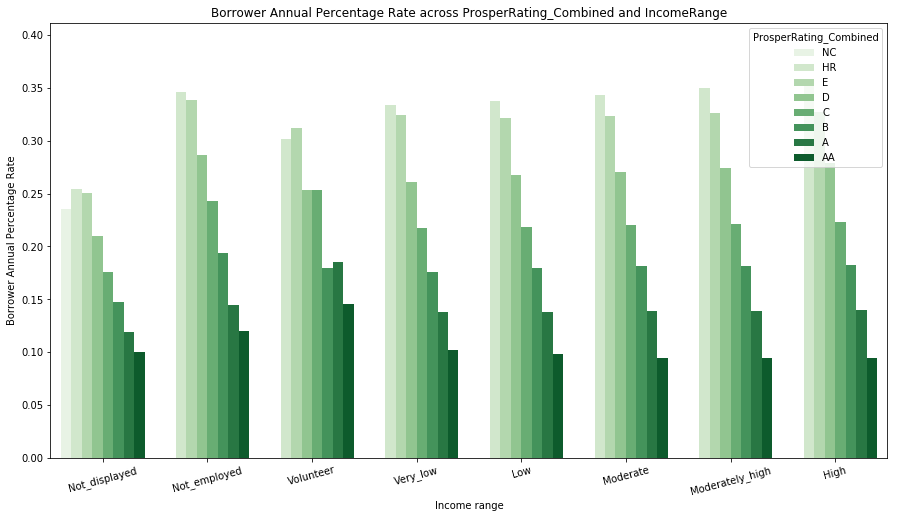

```python
#barplot of Borrower Annual Percentage Rate across ProsperRating_Combined and IncomeRange
plt.figure(figsize=(15,8))
sb.barplot(data=prosper_df, x = 'IncomeRange', y = 'BorrowerAPR', hue = 'ProsperRating_Combined', palette = 'Greens',
             ci='sd', errwidth=0)
plt.xticks(rotation=15)
plt.title('Borrower Annual Percentage Rate across ProsperRating_Combined and IncomeRange')
plt.xlabel('Income range')
plt.ylabel('Borrower Annual Percentage Rate');
```

### Observation after visualisation

Borrowers with 'AA' ProsperRating_Combined value in each of the income range had the least borrowerAPR for its range. Apart from the Not_displayed and Volunteer income range there was a consistent decrease in BorrowerAPR as the ProsperRating_Combined value increased.

### Question 17: What is the effect of Income range across DebtToIncomeRatio and ProsperRating_Combined?

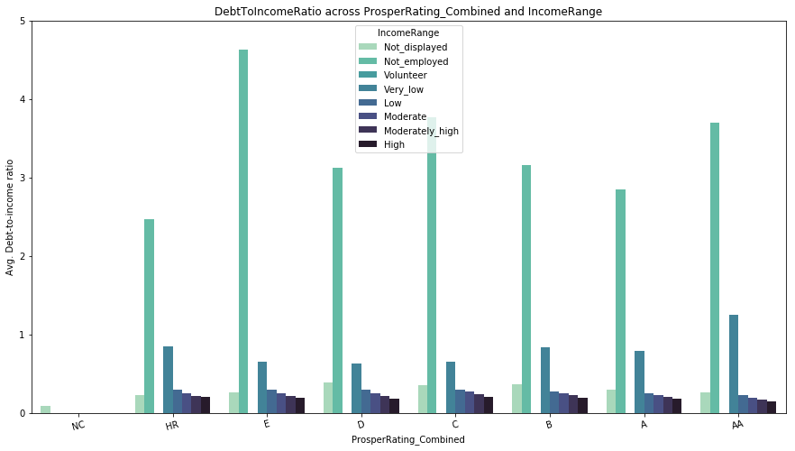

```python
#barplot of Income range across DebtToIncomeRatio and ProsperRating_Combined
plt.figure(figsize=(15,8))
sb.barplot(data=prosper_df, x = 'ProsperRating_Combined', y = 'DebtToIncomeRatio', hue = 'IncomeRange', palette = 'mako_r',
             ci='sd', errwidth=0)
plt.xticks(rotation=15)
plt.title('DebtToIncomeRatio across ProsperRating_Combined and IncomeRange')
plt.xlabel('ProsperRating_Combined')
plt.ylabel('Avg. Debt-to-income ratio')
plt.ylim(0,5) ;
```

### Observation after visualisation

The not employed group has the highest debttoincome ratio across HR to AA borrowers while the voluteers surprisingly have no debttoicome ratio

### Talk about some of the relationships you observed in this part of the investigation. Were there features that strengthened each other in terms of looking at your feature(s) of interest?

IncomeRange strengthened the Year and BorrowerAPR relationship as it showed that the increase in Not_Displayed and Not_employed income range caused the increase for year 2013. It also showed that the exclusion of Not_Displayed, Not_employed and Volunteers income range in year 2014 caused its decrease.  
Borrower Annual Percentage Rate across ProsperRating_Combined and IncomeRange also strengthened each other as it showed that 'AA' ProsperRating_Combined value had the least BorrowerAPR across all the ranges of income.

### Were there any interesting or surprising interactions between features?

In the DebtToIncomeRatio across ProsperRating_Combined and IncomeRange plot, it was surprising to know that the Volunteers(borrowers who earn $0) had no debt-to-income ratio.

## Conclusion

I selected BorrowerAPR as my main feature of interest after I had studied the Prosper loan dataset and selected some features to work with as I could not use the whole 81 columns. Selected features like BorrowerAPR, ProsperRating_Combined, IncomeRange, Year, and Term were plotted to visualize their distributions and examine trends. After the univariate plots of the selected columns, I paired them to find the effect of one variable on the other for the bivariate section. Plotting BorrowerAPR against ProsperRating_Combined showed a negative correlation excluding the No Credit rating which was discontinued after July 2009. BorrowerAPR against IncomeRange also showed a negative correlation for income range from Very_low (\$1-24,999) – High range (\\$100,000+). I selected rows that did not have any ProsperRating_Combined value to explore. I plotted a lineplot with the rows for BorrowerAPR against IncomeRange to see how the borrowers without ratings from Prosper loan fared in terms of their BorrowerAPR. I was surprised to see that their borrower annual percentage rate (borrowerAPR) was even lower than those with ratings which led me to believe that IncomeRange was equally as important as the prosper rating.

## References

1. Udacity lessons
2. www.prosper.com
3. https://stackoverflow.com
4. https://pythonguides.com
5. https://meta.stackexchange.com
6. www.statology.com